# FAA December Analysis

## Airline Departure Delay Patterns

```python
import pandas as pd
import matplotlib.pyplot as p
import seaborn as sns

sns.set(style="whitegrid")

q1 = pd.read_csv("/Users/himabathula/Documents/DSAN/SQL/Homework/miniProject/SQL_Hw4_MiniProject/hw4_mini_project_question1.csv")
q2 = pd.read_csv("/Users/himabathula/Documents/DSAN/SQL/Homework/miniProject/SQL_Hw4_MiniProject/hw4_mini_project_question2.csv")
q3 = pd.read_csv("/Users/himabathula/Documents/DSAN/SQL/Homework/miniProject/SQL_Hw4_MiniProject/hw4_mini_project_question3.csv")
q4 = pd.read_csv("/Users/himabathula/Documents/DSAN/SQL/Homework/miniProject/SQL_Hw4_MiniProject/hw4_mini_project_question4.csv")
q5 = pd.read_csv("/Users/himabathula/Documents/DSAN/SQL/Homework/miniProject/SQL_Hw4_MiniProject/hw4_mini_project_question5.csv")
q6a = pd.read_csv("/Users/himabathula/Documents/DSAN/SQL/Homework/miniProject/SQL_Hw4_MiniProject/hw4_mini_project_question6a.csv")
q6b = pd.read_csv("/Users/himabathula/Documents/DSAN/SQL/Homework/miniProject/SQL_Hw4_MiniProject/hw4_mini_project_question6b.csv")
q7 = pd.read_csv("/Users/himabathula/Documents/DSAN/SQL/Homework/miniProject/SQL_Hw4_MiniProject/hw4_mini_project_question7.csv")
```

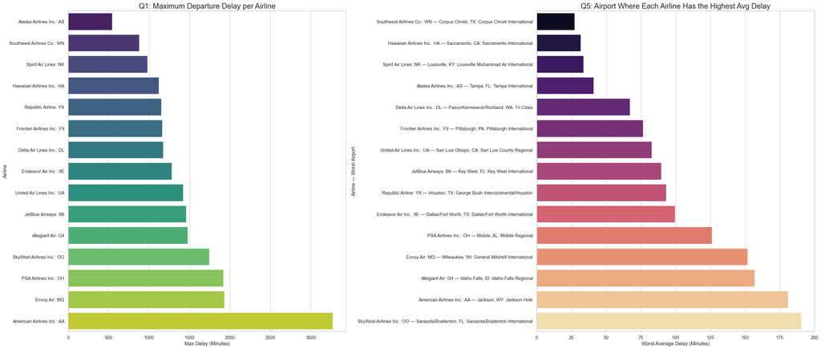

```python
import seaborn as sns
import matplotlib.pyplot as p

sns.set(style="whitegrid")

# Rename columns
q1 = q1.rename(columns={
    "Name": "Airline",
    "Max(DepDelayMinutes)": "MaxDelay"
})

q5 = q5.rename(columns={
    "AirlineName": "Airline",
    "AirportName": "WorstAirport",
    "HighestAvgDelay": "WorstAvgDelay"
})

# Combined label
q5["AirlineAirportLabel"] = q5["Airline"] + " — " + q5["WorstAirport"]

q1_sorted = q1.sort_values("MaxDelay")
q5_sorted = q5.sort_values("WorstAvgDelay")


colors_q1 = sns.color_palette("viridis", len(q1_sorted))
colors_q5 = sns.color_palette("magma", len(q5_sorted))

fig, axes = p.subplots(1, 2, figsize=(28, 12))


sns.barplot(
    data=q1_sorted,
    x="MaxDelay",
    y="Airline",
    hue="Airline",
    dodge=False,
    legend=False,
    palette=colors_q1,
    ax=axes[0]
)

axes[0].set_title("Q1: Maximum Departure Delay per Airline", fontsize=18)
axes[0].set_xlabel("Max Delay (Minutes)")
axes[0].set_ylabel("Airline")


sns.barplot(
    data=q5_sorted,
    x="WorstAvgDelay",
    y="AirlineAirportLabel",
    hue="AirlineAirportLabel",
    dodge=False,
    legend=False,
    palette=colors_q5,
    ax=axes[1]
)

axes[1].set_title("Q5: Airport Where Each Airline Has the Highest Avg Delay", fontsize=18)
axes[1].set_xlabel("Worst Average Delay (Minutes)")
axes[1].set_ylabel("Airline — Worst Airport")

p.tight_layout()
p.show()
```

## Airport Delay Analysis

```python
print("\nAirport with the highest average departure delay:")
print(q4)
```

```
Airport with the highest average departure delay:
                                                Name Code  \
0  Hagerstown, MD: Hagerstown Regional-Richard A....  HGR

   AVG(GREATEST(DepDelay,0))
0                      102.5
```

Among all the airports, HGR showed the highest average departure delay at 102.5 minutes. HGR is a small regional airport. One question that arises is whether the airlines with the largest maximum delays are the same carriers that serve smaller regions like Hagerstown. After a quick search, the answer is yes. Large airlines often serve smaller regional and low-volume airports, which might explain why Hagerstown experiences the highest amount of delays. Additionally, BWI is Maryland’s most well-known international airport, so service may be more limited for smaller airports like HGR.

## Early Departures Analysis

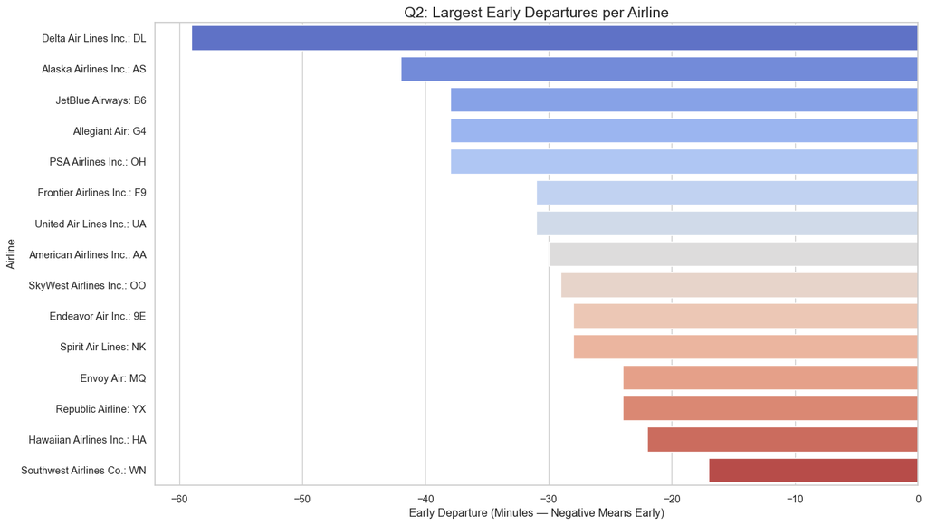

```python
import pandas as pd
import matplotlib.pyplot as plt
import seaborn as sns

sns.set(style="whitegrid")


q2 = pd.read_csv("hw4_mini_project_question2.csv")


q2 = q2.rename(columns={
    "Name": "Airline",
    "Min(DepDelay)": "MaxEarlyDeparture"
})


q2_sorted = q2.sort_values("MaxEarlyDeparture")


colors = sns.color_palette("coolwarm", n_colors=len(q2_sorted))

plt.figure(figsize=(14, 8))
sns.barplot(
    data=q2_sorted,
    x="MaxEarlyDeparture",
    y="Airline",
    hue="Airline",
    legend=False,
    dodge=False,
    palette=colors
)

plt.title("Q2: Largest Early Departures per Airline", fontsize=16)
plt.xlabel("Early Departure (Minutes — Negative Means Early)")
plt.ylabel("Airline")
plt.tight_layout()
plt.show()
```

This dataset details the earliest departures. Delta Air Lines showed the largest early departure, leaving an hour ahead of schedule with Alaska, JetBlue, and Allegiant. If we compare these results with the previous questions, we have additional support to justify which airlines truly are late departures, and how they stand relative to the early departures.

## Cancellation Analysis

```
===== CANCELLATION SUMMARY =====
Total Flights: 590582
Cancelled Flights: 4151
Cancellation Rate: 0.70%
```

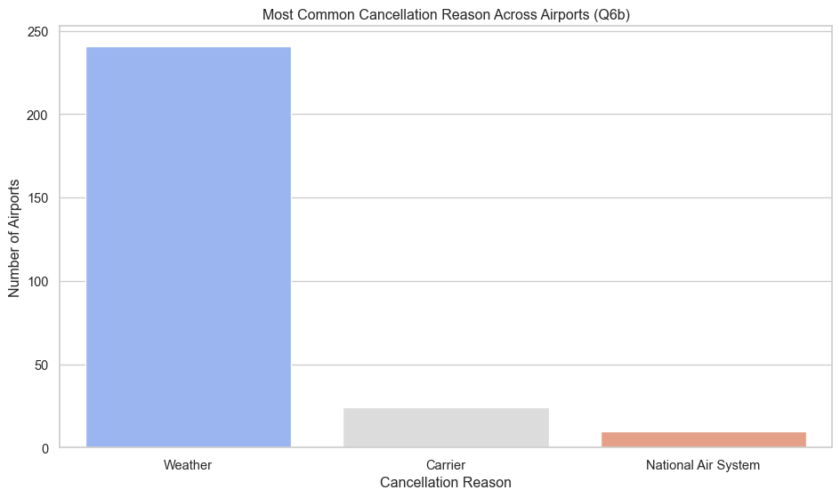

```python
import pandas as pd
import matplotlib.pyplot as plt
import seaborn as sns

sns.set(style="whitegrid")

total_flights = q6a["TotalFlights"].iloc[0]
cancelled_flights = q6a["TotalCancelledFlights"].iloc[0]


cancel_rate = (cancelled_flights / total_flights) * 100

print("\n===== CANCELLATION SUMMARY =====")
print("Total Flights:", total_flights)
print("Cancelled Flights:", cancelled_flights)
print(f"Cancellation Rate: {cancel_rate:.2f}%")


colors_q6 = sns.color_palette("coolwarm", n_colors=q6b["MostFrequentReason"].nunique())

plt.figure(figsize=(10, 6))


sns.countplot(
    data=q6b,
    x="MostFrequentReason",
    hue="MostFrequentReason",
    legend=False,
    palette=colors_q6,
    dodge=False
)

plt.title("Most Common Cancellation Reason Across Airports (Q6b)")
plt.xlabel("Cancellation Reason")
plt.ylabel("Number of Airports")

plt.tight_layout()
plt.show()
```

The cancellation rate table shows that out of 590,582 flights, only 4,151 were canceled, producing a cancellation rate of 0.70%, which is barely 1%. This shows that flights don’t get canceled very often. When examining the reasons behind these cancellations, weather stands out as the dominant cause across the largest number of airports. In contrast, carrier-related cancellations are far less frequent, and National Airspace System (NAS) issues account for an even smaller share, making them the rarest of the three primary causes.

## Weekly Flight Analysis

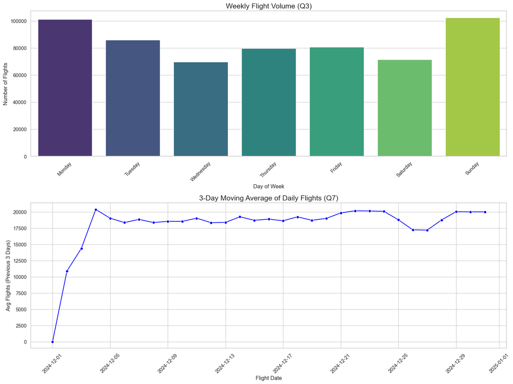

```python
import pandas as pd
import matplotlib.pyplot as plt
import seaborn as sns

sns.set(style="whitegrid")

q3 = pd.read_csv("hw4_mini_project_question3.csv")
q7 = pd.read_csv("hw4_mini_project_question7.csv")


weekday_order = {
    "Monday": 1, "Tuesday": 2, "Wednesday": 3, "Thursday": 4,
    "Friday": 5, "Saturday": 6, "Sunday": 7
}

q3["Order"] = q3["Day"].map(weekday_order)
q3_sorted = q3.sort_values("Order")


q7 = q7.dropna(subset=["FlightDate", "AvgFlightsLast3Days"])


q7["FlightDate"] = pd.to_datetime(q7["FlightDate"])
q7_sorted = q7.sort_values("FlightDate")


colors_q3 = sns.color_palette("viridis", n_colors=len(q3_sorted))

fig, axes = plt.subplots(2, 1, figsize=(16, 12))


sns.barplot(
    data=q3_sorted,
    x="Day",
    y="count(*)",
    hue="Day",
    palette=colors_q3,
    legend=False,
    dodge=False,
    ax=axes[0]
)

axes[0].set_title("Weekly Flight Volume (Q3)", fontsize=16)
axes[0].set_xlabel("Day of Week")
axes[0].set_ylabel("Number of Flights")
axes[0].tick_params(axis="x", rotation=45)


sns.lineplot(
    data=q7_sorted,
    x="FlightDate",
    y="AvgFlightsLast3Days",
    marker="o",
    color="blue",
    ax=axes[1]
)

axes[1].set_title("3-Day Moving Average of Daily Flights (Q7)", fontsize=16)
axes[1].set_xlabel("Flight Date")
axes[1].set_ylabel("Avg Flights (Previous 3 Days)")
axes[1].tick_params(axis="x", rotation=45)

plt.tight_layout()
plt.show()
```

The weekly flight volume chart shows that flights are most frequent on Sundays and Mondays. This could be due to a combination of people returning home from vacation travel or heading out on business trips at the start of the week. It is worth noting that air traffic dips in the middle of the week and gradually picks back up. The least-traveled days are Wednesday and Saturday.The 3-day moving average shows how flight activity fluctuates throughout the month. There is a sharp rise in early December, likely due to people returning home after the Thanksgiving holidays. After this rise, flights stabilize between 18–20k, with a noticeable dip around Christmas and then a gradual increase around New Year’s Day. Last year’s Christmas fell on a Wednesday, so it would be interesting to explore whether the mid-week holiday contributed to the already lower mid-week travel levels.